```python
# Import some useful python libraries
import matplotlib.pyplot as plt
import numpy as np
import scipy.stats
```

# PLUMED masterclass 21.2: Statistical errors in MD (template)

I completed all the exercises for the masterclass in a python notebook that was similar to this one. In this template I will explain how I was able to do this.

## Running PLUMED

To run PLUMED from the python notebook I first set a variable equal to the string that contains the PLUMED input like this:

```python
pex0 = '''d1: READ FILE=data VALUE=d1
          PRINT ARG=d1 FILE=colvar'''
```

```python
# Make a directory to hold the exercise
!mkdir ../Exercises/Exercise_0
# Output the input file above to the plumed.dat file
f = open("../Exercises/Exercise_0/plumed.dat", "w")
f.write( pex0 )
f.close()
# Now run PLUMED driver
!cd ../Exercises/Exercise_1 && plumed driver --noatoms > /dev/null
```

I kept my notebook with the solutions in the solutions directory of the GitHub repository you downloaded at the start of the exercise. When the exercise was completed I thus had a new directory called Exercises in the repo that contained the solutions to all the exercies in directories called Exercise_1, Exercise_2 and so on.

### Reading and plotting the colvar files

You can read in and plot any colvar files that PLUMED produces by using a variant on the command shown below:

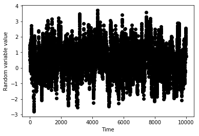

```python
data = np.loadtxt("../data/correlated_data")

plt.plot( data[:,0], data[:,1], 'ko' )
plt.xlabel("Time")
plt.ylabel("Random variable value")
plt.show()
```

If you have not used matplotlib before you can find a nice introductory tutorial here:

https://matplotlib.org/tutorials/introductory/pyplot.html

You can find many other resources by Googling. I am hesitant to give more advice on what I did as I am concious that there might be people who are better at using matplotlib than I am doing this tutorial. If you think you have better scripts for doing some of the plotting in the solution (particularly the 2D free energy) please get in touch as it would be good to improve the resources we are providing.